# dtw_oecd_2022

Kefan Yu

2024-01-05

```r
library(readxl)
library(dtwclust)
library(dtw)
```

```r
reading <- read_excel("../../data/oecd/oecd_2022_clean.xlsx", sheet = "Reading")
math <- read_excel("../../data/oecd/oecd_2022_clean.xlsx", sheet = "Math")
sci <- read_excel("../../data/oecd/oecd_2022_clean.xlsx", sheet = "Science")
reading <- subset(reading, select = -c(...1) )
math <- subset(math, select = -c(...1) )
sci <- subset(sci, select = -c(...1) )
```

# Check unattended countries in 2022 (curiousity)

```r
reading_missing <- list(year2000 = c(),
                year2003 = c(),
                year2006 = c(),
                year2009 = c(),
                year2012 = c(),
                year2015 = c(),
                year2018 = c(),
                year2022 = c())

reading_nan <- which(is.na(reading$`2000`) | is.na(reading$`2003`) | is.na(reading$`2006`) | is.na(reading$`2009`) | is.na(reading$`2012`) | is.na(reading$`2015`) | is.na(reading$`2018`) | is.na(reading$`2022`))

for (reading_index in reading_nan) {

  if (is.na(reading$`2000`[reading_index])){
    reading_missing$year2000 <- append(reading_missing$year2000, reading$Countries[reading_index])
  }
  if (is.na(reading$`2003`[reading_index])){
    reading_missing$year2003 <- append(reading_missing$year2003, reading$Countries[reading_index])
  }
  if (is.na(reading$`2006`[reading_index])){
    reading_missing$year2006 <- append(reading_missing$year2006, reading$Countries[reading_index])
  }
  if (is.na(reading$`2009`[reading_index])){
    reading_missing$year2009 <- append(reading_missing$year2009, reading$Countries[reading_index])
  }
  if (is.na(reading$`2012`[reading_index])){
    reading_missing$year2012 <- append(reading_missing$year2012, reading$Countries[reading_index])
  }
  if (is.na(reading$`2015`[reading_index])){
    reading_missing$year2015 <- append(reading_missing$year2015, reading$Countries[reading_index])
  }
  if (is.na(reading$`2018`[reading_index])){
    reading_missing$year2018 <- append(reading_missing$year2018, reading$Countries[reading_index])
  }
  if (is.na(reading$`2022`[reading_index])){
    reading_missing$year2022 <- append(reading_missing$year2022, reading$Countries[reading_index])
  }
    #cat("Countries: ",reading$Countries[reading_index], "\n")

}

print(reading_missing)
```

```
## $year2000
## [1] "Colombia"        "Costa Rica"      "Estonia"         "Lithuania"
## [5] "Netherlands"     "Slovak Republic" "Slovenia"        "Türkiye"
##
## $year2003
## [1] "Chile"      "Colombia"   "Costa Rica" "Estonia"    "Israel"
## [6] "Lithuania"  "Slovenia"
##
## $year2006
## [1] "Costa Rica"    "United States"
##
## $year2009
## [1] "Costa Rica"
##
## $year2012
## NULL
##
## $year2015
## NULL
##
## $year2018
## [1] "Spain"
##
## $year2022
## [1] "Luxembourg"
```

```r
math_missing <- list(year2000 = c(),
                year2003 = c(),
                year2006 = c(),
                year2009 = c(),
                year2012 = c(),
                year2015 = c(),
                year2018 = c(),
                year2022 = c())

math_nan <- which(is.na(math$`2000`) | is.na(math$`2003`) | is.na(math$`2006`) | is.na(math$`2009`) | is.na(math$`2012`) | is.na(math$`2015`) | is.na(math$`2018`))

for (math_index in math_nan) {

  if (is.na(math$`2000`[math_index])){
    math_missing$year2000 <- append(math_missing$year2000, math$Countries[math_index])
  }
  if (is.na(math$`2003`[math_index])){
    math_missing$year2003 <- append(math_missing$year2003, math$Countries[math_index])
  }
  if (is.na(math$`2006`[math_index])){
    math_missing$year2006 <- append(math_missing$year2006, math$Countries[math_index])
  }
  if (is.na(math$`2009`[math_index])){
    math_missing$year2009 <- append(math_missing$year2009, math$Countries[math_index])
  }
  if (is.na(math$`2012`[math_index])){
    math_missing$year2012 <- append(math_missing$year2012, math$Countries[math_index])
  }
  if (is.na(math$`2015`[math_index])){
    math_missing$year2015 <- append(math_missing$year2015, math$Countries[math_index])
  }
  if (is.na(math$`2018`[math_index])){
    math_missing$year2018 <- append(math_missing$year2018, math$Countries[math_index])
  }

  if (is.na(math$`2022`[math_index])){
    math_missing$year2022 <- append(math_missing$year2022, math$Countries[math_index])
  }
    #cat("Countries: ",reading$Countries[reading_index], "\n")

}

print(math_missing)
```

```
## $year2000
##  [1] "Australia"       "Austria"         "Belgium"         "Canada"
##  [5] "Chile"           "Colombia"        "Costa Rica"      "Czech Republic"
##  [9] "Denmark"         "Estonia"         "Finland"         "France"
## [13] "Germany"         "Greece"          "Hungary"         "Iceland"
## [17] "Ireland"         "Israel"          "Italy"           "Japan"
## [21] "Korea"           "Latvia"          "Lithuania"       "Luxembourg"
## [25] "Mexico"          "Netherlands"     "New Zealand"     "Norway"
## [29] "Poland"          "Portugal"        "Slovak Republic" "Slovenia"
## [33] "Spain"           "Sweden"          "Switzerland"     "Türkiye"
## [37] "United Kingdom"  "United States"
##
## $year2003
## [1] "Chile"      "Colombia"   "Costa Rica" "Estonia"    "Israel"
## [6] "Lithuania"  "Slovenia"
##
## $year2006
## [1] "Costa Rica"
##
## $year2009
## [1] "Costa Rica"
##
## $year2012
## NULL
##
## $year2015
## NULL
##
## $year2018
## NULL
##
## $year2022
## [1] "Luxembourg"
```

```r
sci_missing <- list(year2000 = c(),
                year2003 = c(),
                year2006 = c(),
                year2009 = c(),
                year2012 = c(),
                year2015 = c(),
                year2018 = c(),
                year2022 = c())

sci_nan <- which(is.na(sci$`2000`) | is.na(sci$`2003`) | is.na(sci$`2006`) | is.na(sci$`2009`) | is.na(sci$`2012`) | is.na(sci$`2015`) | is.na(sci$`2018`))

for (sci_index in sci_nan) {

  if (is.na(sci$`2000`[sci_index])){
    sci_missing$year2000 <- append(sci_missing$year2000, sci$Countries[sci_index])
  }
  if (is.na(sci$`2003`[sci_index])){
    sci_missing$year2003 <- append(sci_missing$year2003, sci$Countries[sci_index])
  }
  if (is.na(sci$`2006`[sci_index])){
    sci_missing$year2006 <- append(sci_missing$year2006, sci$Countries[sci_index])
  }
  if (is.na(sci$`2009`[sci_index])){
    sci_missing$year2009 <- append(sci_missing$year2009, sci$Countries[sci_index])
  }
  if (is.na(sci$`2012`[sci_index])){
    sci_missing$year2012 <- append(sci_missing$year2012, sci$Countries[sci_index])
  }
  if (is.na(sci$`2015`[sci_index])){
    sci_missing$year2015 <- append(sci_missing$year2015, sci$Countries[sci_index])
  }
  if (is.na(sci$`2018`[sci_index])){
    sci_missing$year2018 <- append(sci_missing$year2018, sci$Countries[sci_index])
  }
  if (is.na(sci$`2022`[sci_index])){
    sci_missing$year2022 <- append(sci_missing$year2022, sci$Countries[sci_index])
  }
    #cat("Countries: ",reading$Countries[reading_index], "\n")

}
print(sci_missing)
```

```
## $year2000
##  [1] "Australia"       "Austria"         "Belgium"         "Canada"
##  [5] "Chile"           "Colombia"        "Costa Rica"      "Czech Republic"
##  [9] "Denmark"         "Estonia"         "Finland"         "France"
## [13] "Germany"         "Greece"          "Hungary"         "Iceland"
## [17] "Ireland"         "Israel"          "Italy"           "Japan"
## [21] "Korea"           "Latvia"          "Lithuania"       "Luxembourg"
## [25] "Mexico"          "Netherlands"     "New Zealand"     "Norway"
## [29] "Poland"          "Portugal"        "Slovak Republic" "Slovenia"
## [33] "Spain"           "Sweden"          "Switzerland"     "Türkiye"
## [37] "United Kingdom"  "United States"
##
## $year2003
##  [1] "Australia"       "Austria"         "Belgium"         "Canada"
##  [5] "Chile"           "Colombia"        "Costa Rica"      "Czech Republic"
##  [9] "Denmark"         "Estonia"         "Finland"         "France"
## [13] "Germany"         "Greece"          "Hungary"         "Iceland"
## [17] "Ireland"         "Israel"          "Italy"           "Japan"
## [21] "Korea"           "Latvia"          "Lithuania"       "Luxembourg"
## [25] "Mexico"          "Netherlands"     "New Zealand"     "Norway"
## [29] "Poland"          "Portugal"        "Slovak Republic" "Slovenia"
## [33] "Spain"           "Sweden"          "Switzerland"     "Türkiye"
## [37] "United Kingdom"  "United States"
##
## $year2006
## [1] "Costa Rica"
##
## $year2009
## [1] "Costa Rica"
##
## $year2012
## NULL
##
## $year2015
## NULL
##
## $year2018
## NULL
##
## $year2022
## [1] "Luxembourg"
```

From above, we can see that the only country that miss the 2022 exam is Luxembourg.

# Data Cleaning

```r
country = reading[['Countries']]

dtw_reading <- reading[, -1]

dtw_reading
```

```
## # A tibble: 38 × 8
##    `2000` `2003` `2006` `2009` `2012` `2015` `2018` `2022`
##     <dbl>  <dbl>  <dbl>  <dbl>  <dbl>  <dbl>  <dbl>  <dbl>
##  1   528.   525.   513.   515.   512.   503.   503.   498.
##  2   492.   491.   490.   470.   490.   485.   484.   480.
##  3   507.   507.   501.   506.   509.   499.   493.   479.
##  4   534.   528.   527.   524.   523.   527.   520.   507.
##  5   410.    NA    442.   449.   441.   459.   452.   448.
##  6    NA     NA    385.   413.   403.   425.   412.   409.
##  7    NA     NA     NA     NA    441.   427.   426.   415.
##  8   492.   489.   483.   478.   493.   487.   490.   489.
##  9   497.   492.   494.   495.   496.   500.   501.   489.
## 10    NA     NA    501.   501.   516.   519.   523.   511.
## # … with 28 more rows
```

```r
library(zoo)
dtw_reading[] <- t(apply(dtw_reading, 1, function(x) na.locf0(na.locf0(x), fromLast = TRUE)))
dtw_reading
```

```
## # A tibble: 38 × 8
##    `2000` `2003` `2006` `2009` `2012` `2015` `2018` `2022`
##     <dbl>  <dbl>  <dbl>  <dbl>  <dbl>  <dbl>  <dbl>  <dbl>
##  1   528.   525.   513.   515.   512.   503.   503.   498.
##  2   492.   491.   490.   470.   490.   485.   484.   480.
##  3   507.   507.   501.   506.   509.   499.   493.   479.
##  4   534.   528.   527.   524.   523.   527.   520.   507.
##  5   410.   410.   442.   449.   441.   459.   452.   448.
##  6   385.   385.   385.   413.   403.   425.   412.   409.
##  7   441.   441.   441.   441.   441.   427.   426.   415.
##  8   492.   489.   483.   478.   493.   487.   490.   489.
##  9   497.   492.   494.   495.   496.   500.   501.   489.
## 10   501.   501.   501.   501.   516.   519.   523.   511.
## # … with 28 more rows
```

# Reading

```r
reading_lst <- tslist(dtw_reading)

reading_cvi <- list()
for (i in 2:10){
  reading_clust <- tsclust(reading_lst, type = "partitional", k = i, distance = "dtw", centroid = "pam",set.seed(5))
  reading_metric <- cvi(reading_clust, type = "valid", log.base = 10)
  reading_cvi <- append(reading_cvi, list(reading_metric))
}

reading_cvi_ma <- do.call(rbind, reading_cvi)
rw <- c("K2","K3","K4","K5","K6","K7","K8","K9","K10")
rownames(reading_cvi_ma) <- rw
print(reading_cvi_ma)
```

```
##           Sil SF       CH        DB    DBstar          D        COP
## K2  0.4853719  0 31.63019 0.9482539 0.9482539 0.04937098 0.21852053
## K3  0.3136706  0 15.32359 1.2838606 1.7120913 0.03713768 0.18378703
## K4  0.3906602  0 23.32385 0.7859076 1.2041646 0.07333754 0.09245806
## K5  0.3269474  0 17.22915 0.9923231 1.6423669 0.07333754 0.08768589
## K6  0.2768948  0 15.55810 0.9255904 1.6088116 0.07333754 0.07968486
## K7  0.2216652  0 13.52724 0.9946933 1.9871940 0.11201002 0.07782311
## K8  0.2141091  0 13.47592 1.0375826 1.3364987 0.10551399 0.06262258
## K9  0.1883295  0 11.94042 1.0971688 1.5257864 0.12592115 0.06008790
## K10 0.1295059  0 10.47302 0.9973693 1.5740595 0.09734541 0.06015175
```

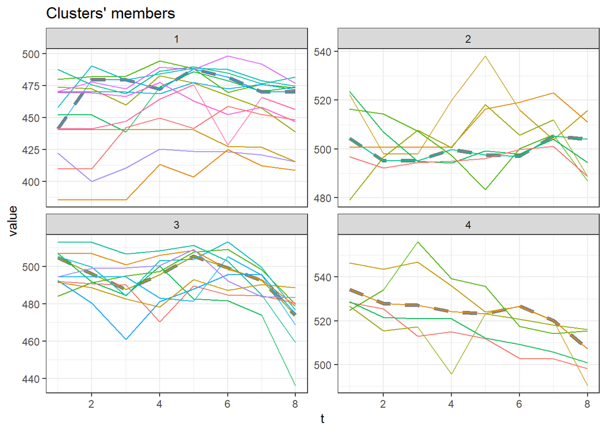

```r
reading_clust_opt <- tsclust(reading_lst, type = "partitional", k = 4, distance = "dtw", centroid = "pam",seed = 725)
plot(reading_clust_opt)
```

```r
print(t(cbind(reading$Countries, cluster = reading_clust_opt@cluster)))
```

```
##         [,1]        [,2]      [,3]      [,4]     [,5]    [,6]
##         "Australia" "Austria" "Belgium" "Canada" "Chile" "Colombia"
## cluster "4"         "3"       "3"       "4"      "1"     "1"
##         [,7]         [,8]             [,9]      [,10]     [,11]     [,12]
##         "Costa Rica" "Czech Republic" "Denmark" "Estonia" "Finland" "France"
## cluster "1"          "3"              "2"       "2"       "4"       "3"
##         [,13]     [,14]    [,15]     [,16]     [,17]     [,18]    [,19]
##         "Germany" "Greece" "Hungary" "Iceland" "Ireland" "Israel" "Italy"
## cluster "3"       "1"      "1"       "3"       "4"       "1"      "1"
##         [,20]   [,21]   [,22]    [,23]       [,24]        [,25]
##         "Japan" "Korea" "Latvia" "Lithuania" "Luxembourg" "Mexico"
## cluster "2"     "4"     "1"      "1"         "1"          "1"
##         [,26]         [,27]         [,28]    [,29]    [,30]
##         "Netherlands" "New Zealand" "Norway" "Poland" "Portugal"
## cluster "3"           "4"           "3"      "2"      "1"
##         [,31]             [,32]      [,33]   [,34]    [,35]         [,36]
##         "Slovak Republic" "Slovenia" "Spain" "Sweden" "Switzerland" "Türkiye"
## cluster "1"               "3"        "3"     "2"      "3"           "1"
##         [,37]            [,38]
##         "United Kingdom" "United States"
## cluster "2"              "2"
```

```r
result_reading_avg = cbind(reading$Countries, cluster = reading_clust_opt@cluster)
result_reading_avg <- as.data.frame(result_reading_avg)

cat("Number of countries in K1: ", nrow(result_reading_avg[result_reading_avg['cluster'] == "1", ]), "\n")
```

```
## Number of countries in K1:  14
```

```r
cat("Number of countries in K2: ", nrow(result_reading_avg[result_reading_avg['cluster'] == "2", ]), "\n")
```

```
## Number of countries in K2:  7
```

```r
cat("Number of countries in K3: ", nrow(result_reading_avg[result_reading_avg['cluster'] == "3", ]), "\n")
```

```
## Number of countries in K3:  11
```

```r
cat("Number of countries in K4: ", nrow(result_reading_avg[result_reading_avg['cluster'] == "4", ]), "\n")
```

```
## Number of countries in K4:  6
```

```r
reading_clust_opt <- tsclust(reading_lst, type = "partitional", k = 4, distance = "dtw", centroid = "pam",seed = 725)

result_reading_avg = cbind(reading$Countries, cluster = reading_clust_opt@cluster)
result_reading_avg <- as.data.frame(result_reading_avg)

cat("Countries in K1: ", result_reading_avg$V1[result_reading_avg$cluster == "1"], "\n")
```

```
## Countries in K1:  Chile Colombia Costa Rica Greece Hungary Israel Italy Latvia Lithuania Luxembourg Mexico Portugal Slovak Republic Türkiye
```

```r
cat("Countries in K2: ", result_reading_avg$V1[result_reading_avg$cluster == "2"], "\n")
```

```
## Countries in K2:  Denmark Estonia Japan Poland Sweden United Kingdom United States
```

```r
cat("Countries in K3: ", result_reading_avg$V1[result_reading_avg$cluster == "3"], "\n")
```

```
## Countries in K3:  Austria Belgium Czech Republic France Germany Iceland Netherlands Norway Slovenia Spain Switzerland
```

```r
cat("Countries in K4: ", result_reading_avg$V1[result_reading_avg$cluster == "4"], "\n")
```

```
## Countries in K4:  Australia Canada Finland Ireland Korea New Zealand
```

```r
reading_clust_opt2 <- tsclust(reading_lst, type = "partitional", k = 4, distance = "dtw", centroid = "pam",seed = 825)

result_reading_avg2 = cbind(reading$Countries, cluster = reading_clust_opt2@cluster)
result_reading_avg2 <- as.data.frame(result_reading_avg2)

cat("Countries in K1: ", result_reading_avg2$V1[result_reading_avg2$cluster == "1"], "\n")
```

```
## Countries in K1:  Australia Canada Finland Ireland Japan Korea New Zealand
```

```r
cat("Countries in K2: ", result_reading_avg2$V1[result_reading_avg2$cluster == "2"], "\n")
```

```
## Countries in K2:  Chile Greece Hungary Israel Italy Latvia Lithuania Luxembourg Portugal Slovak Republic Türkiye
```

```r
cat("Countries in K3: ", result_reading_avg2$V1[result_reading_avg2$cluster == "3"], "\n")
```

```
## Countries in K3:  Austria Belgium Czech Republic Denmark Estonia France Germany Iceland Netherlands Norway Poland Slovenia Spain Sweden Switzerland United Kingdom United States
```

```r
cat("Countries in K4: ", result_reading_avg2$V1[result_reading_avg2$cluster == "4"], "\n")
```

```
## Countries in K4:  Colombia Costa Rica Mexico
```

```r
reading_clust_opt3 <- tsclust(reading_lst, type = "partitional", k = 4, distance = "dtw", centroid = "pam",seed = 925)

result_reading_avg3 = cbind(reading$Countries, cluster = reading_clust_opt3@cluster)
result_reading_avg3 <- as.data.frame(result_reading_avg3)

cat("Countries in K1: ", result_reading_avg3$V1[result_reading_avg3$cluster == "1"], "\n")
```

```
## Countries in K1:  Austria Greece Hungary Israel Italy Latvia Lithuania Luxembourg Portugal Slovak Republic Spain
```

```r
cat("Countries in K2: ", result_reading_avg3$V1[result_reading_avg3$cluster == "2"], "\n")
```

```
## Countries in K2:  Chile Colombia Costa Rica Mexico Türkiye
```

```r
cat("Countries in K3: ", result_reading_avg3$V1[result_reading_avg3$cluster == "3"], "\n")
```

```
## Countries in K3:  Australia Canada Estonia Finland Ireland Japan Korea New Zealand United Kingdom
```

```r
cat("Countries in K4: ", result_reading_avg3$V1[result_reading_avg3$cluster == "4"], "\n")
```

```
## Countries in K4:  Belgium Czech Republic Denmark France Germany Iceland Netherlands Norway Poland Slovenia Sweden Switzerland United States
```

```r
reading_clust_opt4 <- tsclust(reading_lst, type = "partitional", k = 4, distance = "dtw", centroid = "pam",seed = 1025)

result_reading_avg4 = cbind(reading$Countries, cluster = reading_clust_opt4@cluster)
result_reading_avg4 <- as.data.frame(result_reading_avg4)

cat("Countries in K1: ", result_reading_avg4$V1[result_reading_avg4$cluster == "1"], "\n")
```

```
## Countries in K1:  Austria Czech Republic Germany Iceland Italy Latvia Slovenia Spain Switzerland
```

```r
cat("Countries in K2: ", result_reading_avg4$V1[result_reading_avg4$cluster == "2"], "\n")
```

```
## Countries in K2:  Chile Colombia Costa Rica Mexico Türkiye
```

```r
cat("Countries in K3: ", result_reading_avg4$V1[result_reading_avg4$cluster == "3"], "\n")
```

```
## Countries in K3:  Australia Belgium Canada Denmark Estonia Finland France Ireland Japan Korea Netherlands New Zealand Norway Poland Sweden United Kingdom United States
```

```r
cat("Countries in K4: ", result_reading_avg4$V1[result_reading_avg4$cluster == "4"], "\n")
```

```
## Countries in K4:  Greece Hungary Israel Lithuania Luxembourg Portugal Slovak Republic
```

```r
reading_clust_opt5 <- tsclust(reading_lst, type = "partitional", k = 4, distance = "dtw", centroid = "pam",seed = 1125)

result_reading_avg5 = cbind(reading$Countries, cluster = reading_clust_opt5@cluster)
result_reading_avg5 <- as.data.frame(result_reading_avg5)

cat("Countries in K1: ", result_reading_avg5$V1[result_reading_avg5$cluster == "1"], "\n")
```

```
## Countries in K1:  Colombia Costa Rica Mexico
```

```r
cat("Countries in K2: ", result_reading_avg5$V1[result_reading_avg5$cluster == "2"], "\n")
```

```
## Countries in K2:  Chile Greece Hungary Israel Latvia Lithuania Luxembourg Portugal Slovak Republic Türkiye
```

```r
cat("Countries in K3: ", result_reading_avg5$V1[result_reading_avg5$cluster == "3"], "\n")
```

```
## Countries in K3:  Austria Czech Republic Germany Iceland Italy Slovenia Spain Switzerland
```

```r
cat("Countries in K4: ", result_reading_avg5$V1[result_reading_avg5$cluster == "4"], "\n")
```

```
## Countries in K4:  Australia Belgium Canada Denmark Estonia Finland France Ireland Japan Korea Netherlands New Zealand Norway Poland Sweden United Kingdom United States
```

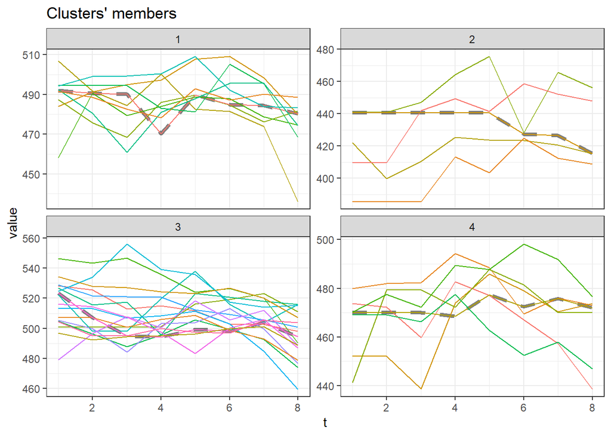

```r
plot(reading_clust_opt4)
```

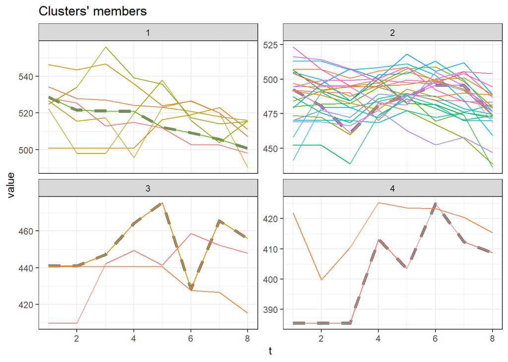

```r
reading_clust_opt_h <- tsclust(reading_lst, type = "h", k = 4, distance = "dtw", seed = 725)
plot(reading_clust_opt_h, type = "sc")
```

```r
#print(t(cbind(reading$Countries, cluster = reading_clust_opt_h@cluster)))

result_reading_avg_h <- as.data.frame(cbind(reading$Countries, cluster = reading_clust_opt_h@cluster))

cat("Countries in K1: ", result_reading_avg_h$V1[result_reading_avg_h$cluster == "1"], "\n")
```

```
## Countries in K1:  Australia Canada Estonia Finland Ireland Japan Korea New Zealand
```

```r
cat("Countries in K2: ", result_reading_avg_h$V1[result_reading_avg_h$cluster == "2"], "\n")
```

```
## Countries in K2:  Austria Belgium Czech Republic Denmark France Germany Greece Hungary Iceland Israel Italy Latvia Lithuania Luxembourg Netherlands Norway Poland Portugal Slovak Republic Slovenia Spain Sweden Switzerland United Kingdom United States
```

```r
cat("Countries in K3: ", result_reading_avg_h$V1[result_reading_avg_h$cluster == "3"], "\n")
```

```
## Countries in K3:  Chile Costa Rica Türkiye
```

```r
cat("Countries in K4: ", result_reading_avg_h$V1[result_reading_avg_h$cluster == "4"], "\n")
```

```
## Countries in K4:  Colombia Mexico
```

```r
result_reading_avg_h = cbind(reading$Countries, cluster = reading_clust_opt_h@cluster)
result_reading_avg_h <- as.data.frame(result_reading_avg_h)

cat("Number of countries in K1: ", nrow(result_reading_avg_h[result_reading_avg_h['cluster'] == "1", ]), "\n")
```

```
## Number of countries in K1:  8
```

```r
cat("Number of countries in K2: ", nrow(result_reading_avg_h[result_reading_avg_h['cluster'] == "2", ]), "\n")
```

```
## Number of countries in K2:  25
```

```r
cat("Number of countries in K3: ", nrow(result_reading_avg_h[result_reading_avg_h['cluster'] == "3", ]), "\n")
```

```
## Number of countries in K3:  3
```

```r
cat("Number of countries in K4: ", nrow(result_reading_avg_h[result_reading_avg_h['cluster'] == "4", ]), "\n")
```

```
## Number of countries in K4:  2
```

By using the hierarchical clustering, we can see that Chile and Colombia are not in the same group but Colomibia and Mexico are still in the same group. I wonder it might be the reason that Colombia and Mexico have very similar scores since they are the least and the second least ranking among all oECD countries. Thus only they are in the same group. It is also notable to see that K2 has 25 countries that share similar trends.

# Math

```r
dtw_math <- math[, -1]

dtw_math <- subset(dtw_math, select = -c(`2000`) )
```

```r
dtw_math[] <- t(apply(dtw_math, 1, function(x) na.locf0(na.locf0(x), fromLast = TRUE)))
```

```r
math_lst <- tslist(dtw_math)
```

```r
math_cvi <- list()
for (i in 2:10){
  math_clust <- tsclust(math_lst, type = "partitional", k = i, distance = "dtw", centroid = "pam",set.seed(4))
  math_metric <- cvi(math_clust, type = "valid", log.base = 10)
  math_cvi <- append(math_cvi, list(math_metric))
}

math_cvi_ma <- do.call(rbind, math_cvi)
rownames(math_cvi_ma) <- rw
print(math_cvi_ma)
```

```
##           Sil SF        CH        DB    DBstar          D        COP
## K2  0.3727900  0  7.307888 8.5764094 8.5764094 0.01543370 0.83653079
## K3  0.4608318  0 39.514902 0.6326258 0.7560057 0.06130563 0.07930888
## K4  0.4060651  0 32.083959 0.8039659 1.2201096 0.06658714 0.06059763
## K5  0.2448900  0 24.998268 0.9863884 1.7388757 0.05309000 0.05802558
## K6  0.1911522  0 19.941431 0.9173051 1.7591511 0.05309000 0.05665654
## K7  0.2187982  0 18.079934 1.2943250 2.1812087 0.05309000 0.05008817
## K8  0.1862947  0 15.434752 1.1663658 2.1100497 0.05309000 0.04871399
## K9  0.2455249  0 14.999470 1.2064775 2.2938825 0.06658714 0.04505689
## K10 0.2172408  0 13.245646 1.1590793 2.3983720 0.06658714 0.04408231
```

We can see that by adding 2022 scores, K=4 is not a good choice anymore, the Silhoutte value ia smaller than K=3’s Sil value, and DB is larger, and there is no significant difference between D values. Thus I choose K = 3.

```r
math_clust_opt <- tsclust(math_lst, type = "partitional", k = 3, distance = "dtw", centroid = "pam",seed = 725)

result_math_avg = cbind(reading$Countries, cluster = math_clust_opt@cluster)
result_math_avg <- as.data.frame(result_math_avg)

cat("Countries in K1: ", result_math_avg$V1[result_math_avg$cluster == "1"], "\n")
```

```
## Countries in K1:  Chile Colombia Costa Rica Mexico Türkiye
```

```r
cat("Countries in K2: ", result_math_avg$V1[result_math_avg$cluster == "2"], "\n")
```

```
## Countries in K2:  France Greece Hungary Israel Italy Latvia Lithuania Luxembourg Norway Poland Portugal Slovak Republic Spain Sweden United States
```

```r
cat("Countries in K3: ", result_math_avg$V1[result_math_avg$cluster == "3"], "\n")
```

```
## Countries in K3:  Australia Austria Belgium Canada Czech Republic Denmark Estonia Finland Germany Iceland Ireland Japan Korea Netherlands New Zealand Slovenia Switzerland United Kingdom
```

```r
math_clust_opt2 <- tsclust(math_lst, type = "partitional", k = 3, distance = "dtw", centroid = "pam",seed = 825)

result_math_avg2 = cbind(reading$Countries, cluster = math_clust_opt2@cluster)
result_math_avg2 <- as.data.frame(result_math_avg2)

cat("Countries in K1: ", result_math_avg2$V1[result_math_avg2$cluster == "1"], "\n")
```

```
## Countries in K1:  Australia Austria Belgium Canada Czech Republic Denmark Estonia Finland Germany Iceland Ireland Japan Korea Netherlands New Zealand Slovenia Switzerland United Kingdom
```

```r
cat("Countries in K2: ", result_math_avg2$V1[result_math_avg2$cluster == "2"], "\n")
```

```
## Countries in K2:  Chile Colombia Costa Rica Mexico Türkiye
```

```r
cat("Countries in K3: ", result_math_avg2$V1[result_math_avg2$cluster == "3"], "\n")
```

```
## Countries in K3:  France Greece Hungary Israel Italy Latvia Lithuania Luxembourg Norway Poland Portugal Slovak Republic Spain Sweden United States
```

```r
math_clust_opt3 <- tsclust(math_lst, type = "partitional", k = 3, distance = "dtw", centroid = "pam",seed = 925)

result_math_avg3 = cbind(reading$Countries, cluster = math_clust_opt3@cluster)
result_math_avg3 <- as.data.frame(result_math_avg3)

cat("Countries in K1: ", result_math_avg3$V1[result_math_avg3$cluster == "1"], "\n")
```

```
## Countries in K1:  France Greece Hungary Israel Italy Latvia Lithuania Luxembourg Norway Poland Portugal Slovak Republic Spain Sweden United States
```

```r
cat("Countries in K2: ", result_math_avg3$V1[result_math_avg3$cluster == "2"], "\n")
```

```
## Countries in K2:  Chile Colombia Costa Rica Mexico Türkiye
```

```r
cat("Countries in K3: ", result_math_avg3$V1[result_math_avg3$cluster == "3"], "\n")
```

```
## Countries in K3:  Australia Austria Belgium Canada Czech Republic Denmark Estonia Finland Germany Iceland Ireland Japan Korea Netherlands New Zealand Slovenia Switzerland United Kingdom
```

Since K only equals to 3, there is no variation among different seeds. We can see that Chile, Colombia, Costa Rica, Mexico, Türkiye form a single group.

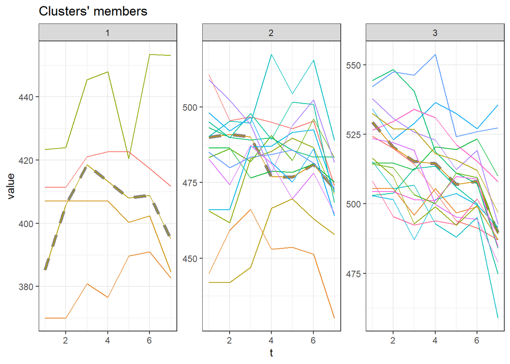

```r
plot(math_clust_opt)
```

When K is 3, the clustering results are usually based on the score range (like the sci result). From the graph above, we can see that it is divided into 450-500 (middle score), 380-440(low score), 475 - 550 (high score).

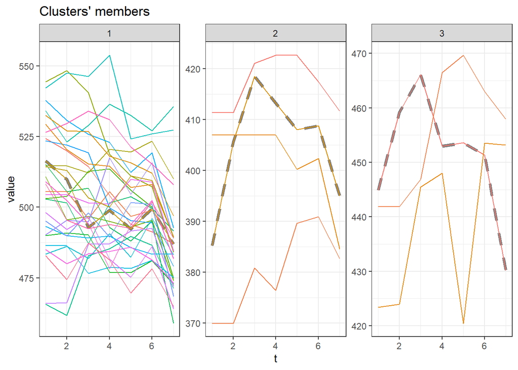

```r
math_clust_opt_h <- tsclust(math_lst, type = "h", k = 3, distance = "dtw", seed = 725)
plot(math_clust_opt_h, type="sc")
```

```r
result_math_avg_h = cbind(reading$Countries, cluster = math_clust_opt_h@cluster)
result_math_avg_h <- as.data.frame(result_math_avg_h)

cat("Countries in K1: ", result_math_avg_h$V1[result_math_avg_h$cluster == "1"], "\n")
```

[output not shown]

```r
cat("Countries in K2: ", result_math_avg_h$V1[result_math_avg_h$cluster == "2"], "\n")
```

```
## Countries in K2:  Chile Colombia Costa Rica Mexico
```

```r
cat("Countries in K3: ", result_math_avg_h$V1[result_math_avg_h$cluster == "3"], "\n")
```

```
## Countries in K3:  Greece Israel Türkiye
```

The hierarchical clustering throw every country except Chile, Colombia, Costa Rica, Mexico, Türkiye, Greece and Israel into one cluster, and divide them into two clusters. Such clustering is not based on the similarity of each sequence, but based on their score ranges.

# Science

```r
dtw_sci <- sci[, -1]
dtw_sci <- subset(dtw_sci, select = -c(`2000`,`2003`) )
dtw_sci[] <- t(apply(dtw_sci, 1, function(x) na.locf0(na.locf0(x), fromLast = TRUE)))
sci_lst <- tslist(dtw_sci)


sci_cvi <- list()
for (i in 2:10){
  sci_clust <- tsclust(sci_lst, type = "partitional", k = i, distance = "dtw", centroid = "pam",set.seed(4))
  sci_metric <- cvi(sci_clust, type = "valid", log.base = 10)
  sci_cvi <- append(sci_cvi, list(sci_metric))
}

sci_cvi_ma <- do.call(rbind, sci_cvi)
rownames(sci_cvi_ma) <- rw
print(sci_cvi_ma)
```

```
##           Sil SF       CH        DB    DBstar          D        COP
## K2  0.7017157  0 39.95383 0.4836848 0.4836848 0.13883902 0.15845794
## K3  0.4903178  0 36.89864 0.5099049 0.5775587 0.04753541 0.09374899
## K4  0.4081080  0 29.21207 0.8373458 1.1051032 0.07058018 0.07429428
## K5  0.3191470  0 24.68315 0.9867129 1.7320931 0.07058018 0.06580427
## K6  0.3396752  0 24.47524 0.8544744 1.3651284 0.15942162 0.05205491
## K7  0.3011587  0 22.13376 1.1116929 1.8172232 0.14680029 0.04863504
## K8  0.3107981  0 19.32544 0.9880525 1.8211250 0.14680029 0.04648038
## K9  0.2360732  0 15.76380 0.8004443 1.7408475 0.15942162 0.04626164
## K10 0.2013819  0 13.82551 0.7889205 1.9421444 0.15942162 0.04528698
```

```r
sci_clust_opt <- tsclust(sci_lst, type = "partitional", k = 3, distance = "dtw", centroid = "pam",seed = 725)
result_sci_avg = cbind(reading$Countries, cluster = sci_clust_opt@cluster)
result_sci_avg <- as.data.frame(result_sci_avg)

cat("Countries in K1: ", result_sci_avg$V1[result_sci_avg$cluster == "1"], "\n")
```

```
## Countries in K1:  Chile Colombia Costa Rica Greece Israel Mexico Türkiye
```

```r
cat("Countries in K2: ", result_sci_avg$V1[result_sci_avg$cluster == "2"], "\n")
```

```
## Countries in K2:  Austria Belgium Czech Republic Denmark France Hungary Iceland Italy Latvia Lithuania Luxembourg Norway Poland Portugal Slovak Republic Spain Sweden United States
```

```r
cat("Countries in K3: ", result_sci_avg$V1[result_sci_avg$cluster == "3"], "\n")
```

```
## Countries in K3:  Australia Canada Estonia Finland Germany Ireland Japan Korea Netherlands New Zealand Slovenia Switzerland United Kingdom
```

```r
sci_clust_opt <- tsclust(sci_lst, type = "partitional", k = 3, distance = "dtw", centroid = "pam",seed = 825)
result_sci_avg = cbind(reading$Countries, cluster = sci_clust_opt@cluster)
result_sci_avg <- as.data.frame(result_sci_avg)

cat("Countries in K1: ", result_sci_avg$V1[result_sci_avg$cluster == "1"], "\n")
```

```
## Countries in K1:  Australia Canada Estonia Finland Japan Korea New Zealand
```

```r
cat("Countries in K2: ", result_sci_avg$V1[result_sci_avg$cluster == "2"], "\n")
```

```
## Countries in K2:  Chile Colombia Costa Rica Greece Israel Mexico Türkiye
```

```r
cat("Countries in K3: ", result_sci_avg$V1[result_sci_avg$cluster == "3"], "\n")
```

```
## Countries in K3:  Austria Belgium Czech Republic Denmark France Germany Hungary Iceland Ireland Italy Latvia Lithuania Luxembourg Netherlands Norway Poland Portugal Slovak Republic Slovenia Spain Sweden Switzerland United Kingdom United States
```

```r
sci_clust_opt <- tsclust(sci_lst, type = "partitional", k = 3, distance = "dtw", centroid = "pam",seed = 925)
result_sci_avg = cbind(reading$Countries, cluster = sci_clust_opt@cluster)
result_sci_avg <- as.data.frame(result_sci_avg)

cat("Countries in K1: ", result_sci_avg$V1[result_sci_avg$cluster == "1"], "\n")
```

```
## Countries in K1:  Austria Belgium Czech Republic Denmark France Germany Hungary Iceland Ireland Italy Latvia Lithuania Luxembourg Netherlands Norway Poland Portugal Slovak Republic Slovenia Spain Sweden Switzerland United Kingdom United States
```

```r
cat("Countries in K2: ", result_sci_avg$V1[result_sci_avg$cluster == "2"], "\n")
```

```
## Countries in K2:  Chile Colombia Costa Rica Greece Israel Mexico Türkiye
```

```r
cat("Countries in K3: ", result_sci_avg$V1[result_sci_avg$cluster == "3"], "\n")
```

```
## Countries in K3:  Australia Canada Estonia Finland Japan Korea New Zealand
```

```r
sci_clust_opt <- tsclust(sci_lst, type = "partitional", k = 3, distance = "dtw", centroid = "pam",seed = 1025)
result_sci_avg = cbind(reading$Countries, cluster = sci_clust_opt@cluster)
result_sci_avg <- as.data.frame(result_sci_avg)

cat("Countries in K1: ", result_sci_avg$V1[result_sci_avg$cluster == "1"], "\n")
```

```
## Countries in K1:  Australia Canada Estonia Finland Germany Ireland Japan Korea Netherlands New Zealand Slovenia Switzerland United Kingdom
```

```r
cat("Countries in K2: ", result_sci_avg$V1[result_sci_avg$cluster == "2"], "\n")
```

```
## Countries in K2:  Chile Colombia Costa Rica Greece Israel Mexico Türkiye
```

```r
cat("Countries in K3: ", result_sci_avg$V1[result_sci_avg$cluster == "3"], "\n")
```

```
## Countries in K3:  Austria Belgium Czech Republic Denmark France Hungary Iceland Italy Latvia Lithuania Luxembourg Norway Poland Portugal Slovak Republic Spain Sweden United States
```

```r
sci_clust_opt <- tsclust(sci_lst, type = "partitional", k = 3, distance = "dtw", centroid = "pam",seed = 1125)
result_sci_avg = cbind(reading$Countries, cluster = sci_clust_opt@cluster)
result_sci_avg <- as.data.frame(result_sci_avg)

cat("Countries in K1: ", result_sci_avg$V1[result_sci_avg$cluster == "1"], "\n")
```

```
## Countries in K1:  Chile Colombia Costa Rica Greece Israel Mexico Türkiye
```

```r
cat("Countries in K2: ", result_sci_avg$V1[result_sci_avg$cluster == "2"], "\n")
```

```
## Countries in K2:  Denmark France Hungary Iceland Italy Latvia Lithuania Luxembourg Norway Portugal Slovak Republic Spain Sweden United States
```

```r
cat("Countries in K3: ", result_sci_avg$V1[result_sci_avg$cluster == "3"], "\n")
```

```
## Countries in K3:  Australia Austria Belgium Canada Czech Republic Estonia Finland Germany Ireland Japan Korea Netherlands New Zealand Poland Slovenia Switzerland United Kingdom
```

```r
sci_clust_opt <- tsclust(sci_lst, type = "partitional", k = 3, distance = "dtw", centroid = "pam",seed = 1225)
result_sci_avg = cbind(reading$Countries, cluster = sci_clust_opt@cluster)
result_sci_avg <- as.data.frame(result_sci_avg)

cat("Countries in K1: ", result_sci_avg$V1[result_sci_avg$cluster == "1"], "\n")
```

```
## Countries in K1:  Chile Colombia Costa Rica Greece Israel Mexico Türkiye
```

```r
cat("Countries in K2: ", result_sci_avg$V1[result_sci_avg$cluster == "2"], "\n")
```

```
## Countries in K2:  Australia Canada Estonia Finland Japan Korea New Zealand
```

```r
cat("Countries in K3: ", result_sci_avg$V1[result_sci_avg$cluster == "3"], "\n")
```

```
## Countries in K3:  Austria Belgium Czech Republic Denmark France Germany Hungary Iceland Ireland Italy Latvia Lithuania Luxembourg Netherlands Norway Poland Portugal Slovak Republic Slovenia Spain Sweden Switzerland United Kingdom United States
```

Since seed 825, 925, 1225 converge, we use 1225 for analysis.

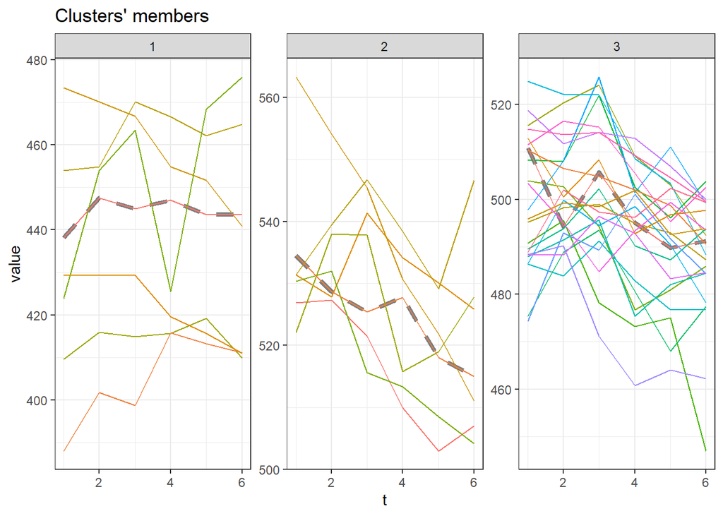

```r
plot(sci_clust_opt)
```

Similar for math, the groups are generated based on score range. Thus it makes sense that there are many countries in the middle score cluster.

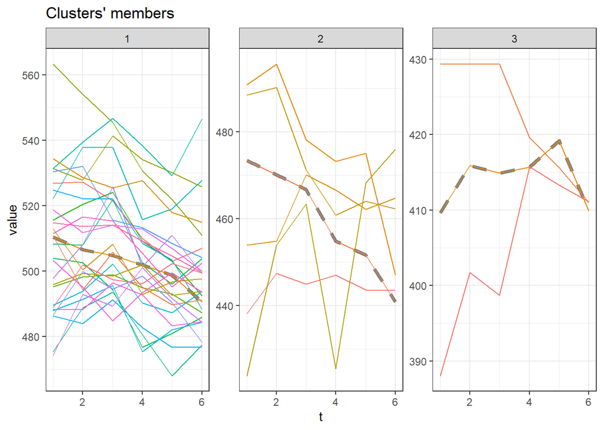

```r
sci_clust_opt_h <- tsclust(sci_lst, type = "h", k = 3, distance = "dtw", seed = 725)
plot(sci_clust_opt_h, type="sc")
```

```r
print(t(cbind(reading$Countries, cluster = sci_clust_opt_h@cluster)))
```

```
##         1           2         3         4        5       6
##         "Australia" "Austria" "Belgium" "Canada" "Chile" "Colombia"
## cluster "1"         "1"       "1"       "1"      "2"     "3"
##         7            8                9         10        11        12
##         "Costa Rica" "Czech Republic" "Denmark" "Estonia" "Finland" "France"
## cluster "3"          "1"              "1"       "1"       "1"       "1"
##         13        14       15        16        17        18       19
##         "Germany" "Greece" "Hungary" "Iceland" "Ireland" "Israel" "Italy"
## cluster "1"       "2"      "1"       "2"       "1"       "2"      "1"
##         20      21      22       23          24           25
##         "Japan" "Korea" "Latvia" "Lithuania" "Luxembourg" "Mexico"
## cluster "1"     "1"     "1"      "1"         "1"          "3"
##         26            27            28       29       30
##         "Netherlands" "New Zealand" "Norway" "Poland" "Portugal"
## cluster "1"           "1"           "1"      "1"      "1"
##         31                32         33      34       35            36
##         "Slovak Republic" "Slovenia" "Spain" "Sweden" "Switzerland" "Türkiye"
## cluster "2"               "1"        "1"     "1"      "1"           "2"
##         37               38
##         "United Kingdom" "United States"
## cluster "1"              "1"
```